返回主页

# ETF轮动策略

## 资产选择

轮动资产选择黄金(ETF基金:518880)，纳指(ETF基金:513100)，创业板(ETF基金:159915)和沪深300(ETF基金:510300)。

黄金、纳指、创业板和沪深300代表了不同类型、风格和市场的资产，它们之间具有一定的互补性。通过将这些资产组合在一起，可以实现投资组合的多样化和风险分散。在选择资产时，需要考虑到资产的特性和风险收益特征，以及投资者的风险偏好和目标。

## 策略描述

该策略的基本思想是始终持有过去一段时间涨幅大（动量强）的资产，在4种资产间进行轮动。构建步骤如下：

1. 每日计算每个ETF过去21个交易日（含计算当日）的涨跌幅作为动量。
2. 比较动量，选择动量更大的ETF作为投资标的，以当日收盘价买入对应的ETF基金。
3. 持有所购买的ETF基金，直到下一个调仓日。
4. 每个调仓日重复以上步骤，根据涨幅更大的指数进行轮动投资。

```python
import warnings
warnings.filterwarnings('ignore')
import time
import akshare as ak
import numpy as np
import pandas as pd
import quantstats as qs
import matplotlib.pyplot as plt
import matplotlib.ticker as ticker
```

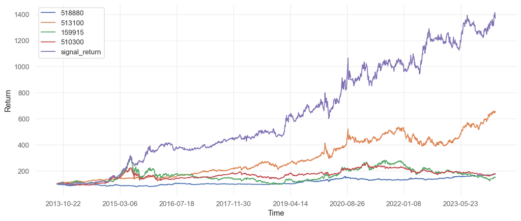

```python
etf_data = {}
etf_symbols = ['518880', '513100', '159915', '510300']
# etf_symbols = ['518880', '513100', '159915', '510210']
window = 21

# 获取 ETF 历史数据
for symbol in etf_symbols:
    etf_df = ak.fund_etf_hist_em(symbol=symbol, period="daily", adjust='hfq')[['日期', '收盘']] \
            .rename(columns={'日期': 'date', '收盘': symbol}).set_index('date')
    etf_data[symbol] = etf_df

# 合并数据并对齐
data = pd.concat(list(etf_data.values()), axis=1).dropna()
data.index = pd.to_datetime(data.index)

# 计算每日涨跌幅和滚动收益率
for symbol in etf_symbols:
    column_name = f"{symbol}"
    data[f"{column_name}_day_return"] = data[column_name].rolling(2).apply(lambda x: x[-1]/x[0]-1)
    data[f"{column_name}_return"] = data[column_name].rolling(window=window).apply(lambda x: x[-1]/x[0]-1)
    data[f"{column_name}_ma"] = data[column_name].rolling(window=window).mean()

# 去掉缺失值
data = data.dropna()

data['signal'] = data[[f"{symbol}_return" for symbol in etf_symbols]].idxmax(axis=1).str.split('_').str[0]
data['signal'] = data['signal'].shift(1)
data = data.dropna()
data["signal_return"] = (np.cumprod(data.apply(lambda row: row[f'{row["signal"]}_day_return'], axis=1) + 1) * 100)

# 计算累计收益率
for symbol in etf_symbols:
    column_name = f"{symbol}_return"
    data[column_name] = 100 * data[f"{symbol}"] / data[f"{symbol}"].values[0]

# 绘制曲线图
fig, ax = plt.subplots(figsize=(15, 6))
ax.set_xlabel('Time')
ax.set_ylabel('Return')

for symbol in etf_symbols:
    column_name = f"{symbol}_return"
    ax.plot(data[column_name].index, data[column_name].values)

ax.plot(data["signal_return"].index, data["signal_return"].values)
ax.legend(etf_symbols + ["signal_return"])
ax.xaxis.set_major_locator(ticker.MultipleLocator(500))
```

```python
# 计算策略表现指标
result = {}
for symbol in etf_symbols + ["signal",]:
    column_name = f"{symbol}_return"
    result[column_name] = []
    for stat in ["avg_return", "volatility", "sharpe", "max_drawdown", "win_rate"]:
        r = getattr(qs.stats, stat)(data[column_name])
        result[column_name].append(r)

result = pd.DataFrame(result, index=["avg_return", "volatility", "sharpe", "max_drawdown", "win_rate"])

result
```

|  | 518880_return | 513100_return | 159915_return | 510300_return | signal_return |
| --- | --- | --- | --- | --- | --- |
| avg_return | 0.000262 | 0.000844 | 0.000368 | 0.000312 | 0.001151 |
| volatility | 0.126997 | 0.209372 | 0.325672 | 0.216039 | 0.239277 |
| sharpe | 0.508784 | 0.987827 | 0.281176 | 0.359398 | 1.190342 |
| max_drawdown | -0.233463 | -0.285680 | -0.695778 | -0.443748 | -0.247842 |
| win_rate | 0.516116 | 0.536615 | 0.492714 | 0.504935 | 0.524772 |